# How the ML Competitiveness Model Works

A Visual Explainer — No Machine Learning Background Required

Author

Net Zero Industrial Policy Lab · Johns Hopkins SAIS

Published

May 20, 2026

**About this document**

This explainer was written for colleagues at NZIPL and incoming staff who are curious about how the ML competitiveness model works. **No maths, no code** — just intuition, pictures, and real data from the Solar technology value chain. The model was built by **Ishana Ratan** (NZIPL Research Associate) using Python’s `scikit-learn` and `shap` libraries.

## 1 The Question We Are Trying to Answer

The core question is deceptively simple:

> **Given everything we know about a country’s trade patterns today, how likely is it to be a competitive exporter of a clean technology product in the future?**

For example: Should we expect India to become competitive in Solar modules? What about Vietnam in Wind components, or Chile in Battery materials?

We want a *data-driven* answer — one that looks at hundreds of countries and products simultaneously, learns patterns from history, and produces a score between 0 and 1 for each country and technology.

## 2 Step 1 — What Does “Competitive” Mean Here?

We define **competitiveness** using a standard trade-economics concept: the **Revealed Comparative Advantage (RCA)**.

The idea is simple: a country is considered *competitive* in a product if it exports **more than its fair share** of that product relative to the world.

$$\text{RCA}_{c,p} = \frac{\text{Exports}_{c,p} / \text{Total exports}_c}{\text{World exports}_p / \text{Total world trade}}$$

- RCA **> 1** → the country exports proportionally more of product $p$ than the world average → **Competitive**
- RCA **≤ 1** → the country exports proportionally less → **Not (yet) competitive**

This converts a continuous trade number into a binary label: **1 = competitive**, **0 = not competitive**. This binary label is what the model learns to predict.

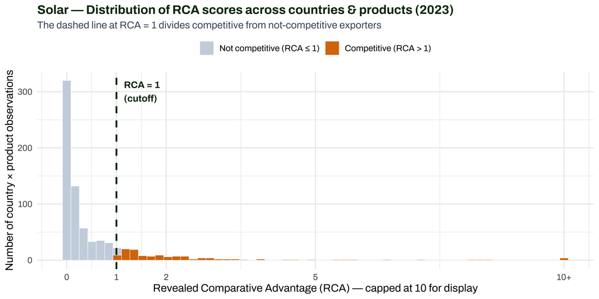

Distribution of RCA scores across countries and Solar products. The cutoff at 1 defines the binary competitive / not-competitive label.

**Why binary?**

A binary label (competitive / not competitive) makes the model simpler and more interpretable than trying to predict exact RCA values. It also avoids the model being dominated by extreme exporters like China. Statistical advisor **Ben Bagozzi** (University of Delaware) recommended this approach specifically for this kind of imbalanced trade data.

## 3 Step 2 — What Does the Model Learn From?

The model takes as input a set of **features** (also called predictors or variables) describing each country’s current economic and trade situation. These were carefully chosen to capture different dimensions of industrial capability:

| Feature type | Examples | Economic intuition |
| --- | --- | --- |
| **Trade in related products** | RCA in solar wafers, polysilicon, glass | “Can you make the ingredients?” |
| **Trade in similar products** | Proximity-weighted export similarity | “Are neighbouring capabilities present?” |
| **Product centrality** | Eigenvector centrality in export network | “Is the country well-connected in trade?” |
| **Foreign direct investment** | FDI in solar manufacturing | “Are companies investing here?” |
| **Trade barriers** | Tariffs, non-tariff measures | “Can products flow in/out?” |
| **Domestic conditions** | GDP, population, institutional quality | “Is the broader environment supportive?” |

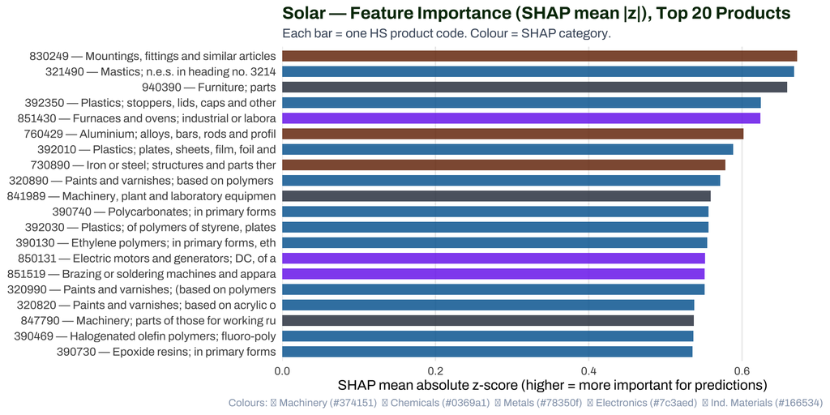

Solar — Top 20 most important features by SHAP mean |z|. Higher = more influential in the model’s predictions.

## 4 Step 3 — The Random Forest Algorithm

The model uses a **Random Forest** — an ensemble of many decision trees. Here is the intuition:

### 4.1 What is a Decision Tree?

Think of it as a flowchart of yes/no questions. For example:

```
Is RCA in polysilicon > 0.8?
  YES → Is GDP per capita > $8,000?
          YES → Predict: COMPETITIVE (1)
          NO  → Predict: NOT COMPETITIVE (0)
  NO  → Is FDI in solar > $200M?
          YES → Predict: COMPETITIVE (1)
          NO  → Predict: NOT COMPETITIVE (0)
```

Each question splits the data into two groups. The tree keeps asking questions until it reaches a leaf node (a final prediction). Each leaf says: “among all the historical cases that matched this combination of conditions, X% were competitive.”

### 4.2 What makes it a *Forest*?

Instead of one tree, the Random Forest grows **hundreds of trees** (typically 100–500), each trained on:

- A **random subsample** of the training data (so each tree sees different examples)
- A **random subset of features** at each split (so trees don’t all ask the same questions)

The final prediction is the **vote count**: if 73 out of 100 trees classify a country as competitive, the model’s predicted competitiveness score is **0.73**.

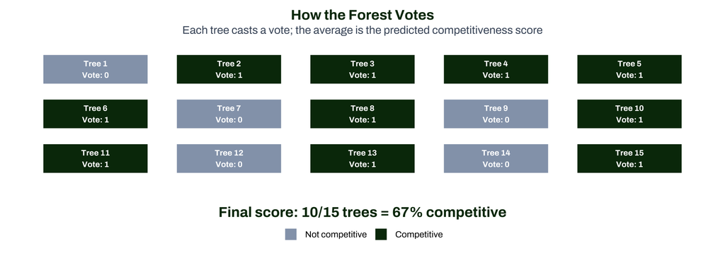

Schematic of the Random Forest voting process. Each tree produces a 0/1 prediction; the forest averages them into a probability score.

### 4.3 Why Random Forest and not a simpler model?

The team evaluated several approaches (from the methodology notes):

| Model | Pros | Cons |
| --- | --- | --- |
| Linear Regression | Simple, interpretable | Assumes straight-line relationships; struggles with interactions |
| Lasso/Ridge | Handles many variables | Still assumes linear relationships |
| **Random Forest** | **Captures non-linear patterns and interactions** | Slightly harder to interpret |
| Gradient Boosting | Often highest accuracy | Prone to overfitting; harder to tune |

Random Forest was chosen because clean-tech competitiveness involves **conditional relationships** — e.g., having RCA in polysilicon only matters for Solar competitiveness if a country also has basic manufacturing infrastructure. Linear models cannot capture these “and” conditions; decision trees can.

**Model performance (Solar):** Area under ROC curve ≈ 0.90 (excellent; a random model would score 0.50).

## 5 Step 4 — What are SHAP Values?

Once the model is trained, a natural question is: *why* did it predict a particular score? SHAP (SHapley Additive exPlanations) provides the answer.

### 5.1 The intuition

Imagine you want to know why a country got a high competitiveness score of 0.78. SHAP asks: **how much did each feature “push” the score up or down from the baseline?**

For example: - High RCA in silicon wafers: **pushed score UP** by +0.18 - Low FDI in solar: **pushed score DOWN** by −0.05 - High GDP: **pushed score UP** by +0.08 - Low trade barriers: **pushed score UP** by +0.12

The SHAP values sum to the difference between the country’s predicted score (0.78) and the average score across all countries (say, 0.45).

### 5.2 SHAP Feature Importance: aggregating across all countries

To get an overall measure of how important each feature is across the entire dataset, NZIPL uses the **mean absolute z-score of SHAP values** (`shap_mean_z`):

1. For each (country, year) observation, SHAP calculates a push value for every feature
2. Those push values are standardised (converted to z-scores) to make them comparable across features with different units
3. The mean of the absolute z-scores across all observations gives the overall importance of each feature

A feature with `shap_mean_z = 2.5` is more important than one with `shap_mean_z = 0.3` — it has a larger, more consistent effect on predictions across the dataset.

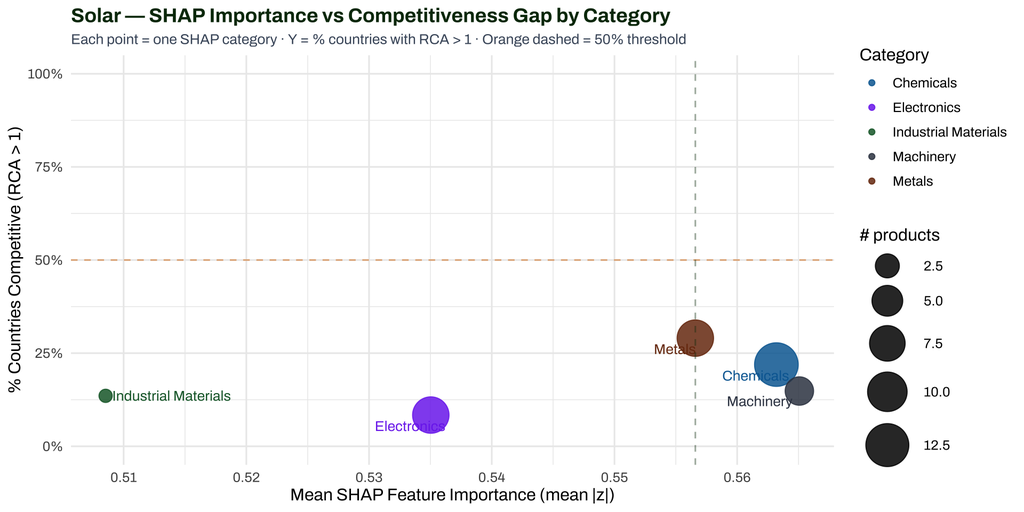

Solar — Mean SHAP importance vs. % countries competitive per category. Points above the orange line have more than half of countries competitive; points to the right are more predictive of overall competitiveness.

## 6 Step 5 — What the Scores Mean

After training, the model is applied to all countries and years to produce **Predicted Competitiveness (PC) scores** — a number between 0 and 1 for each (country × technology × year) combination.

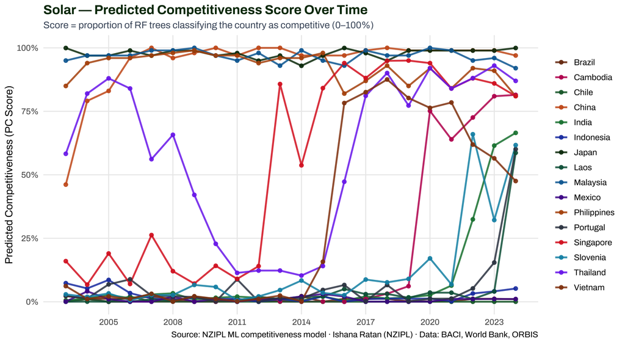

Solar — Predicted Competitiveness scores over time for a selection of countries. Rising scores suggest the model detects strengthening competitive fundamentals.

**How to read the PC score**

- A score of **0.85** means 85 out of 100 trees in the model classified that country as competitive in Solar — strong signal
- A score of **0.50** is ambiguous — the model is uncertain
- A score of **0.10** means the model sees little evidence of competitive fundamentals at this time
- Scores change over time as the country’s trade patterns, FDI, and policies evolve

## 7 Step 6 — From ML Scores to Policy Intelligence

The NZIPL Clean Value Chain Explorer combines the ML scores with the Green Dictionary and BACI bilateral trade data to answer policy-relevant questions:

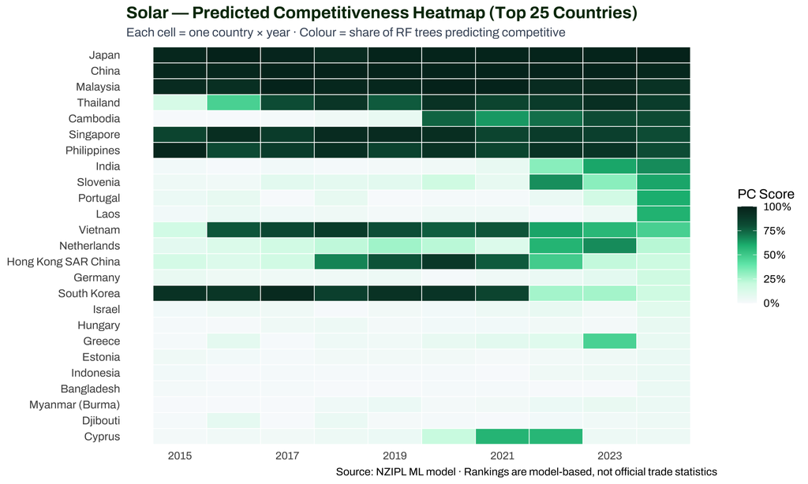

Solar — Predicted Competitiveness rankings across countries and recent years. Darker green = stronger competitive fundamentals.

### 7.1 What can this tell a policymaker?

1. **Identify emerging competitors early**: A country with a rising PC score — even if it does not yet have high RCA — may be building the product-space and capability foundations for future competitiveness
2. **Target industrial policy at capability gaps**: The feature importance chart (Step 4) tells you *which products* are most predictive of competitiveness. Countries missing those products face structural gaps
3. **Distinguish structural vs cyclical changes**: A country whose PC score drops sharply in one year but recovers is likely experiencing a trade shock; a country whose score steadily declines has structural issues
4. **Compare value chain positions**: Countries that are competitive in Upstream (Raw Material, Processed Material) vs Downstream (Final Product) are in structurally different positions with different policy implications

## 8 Appendix: Technical Summary

ML Pipeline — Technical Summary

| Component | Detail |
| --- | --- |
| Model type | Random Forest (binary classification) |
| Target variable | Binary RCA > 1 in the final product (e.g. solar modules) |
| Training data | Country-level trade, FDI, policy, institutional indicators · 2003–2024 |
| Feature categories | Trade in related/similar products, product-space centrality, FDI, trade barriers, domestic conditions |
| Key hyperparameters | 100–500 trees · random feature subsets at each split · bootstrap sampling |
| Predicted output | PC Score = proportion of trees classifying country as competitive (0–1) |
| Feature importance | SHAP mean &#124;z&#124; = standardised average push of each feature across all predictions |
| Model performance | Solar AUC (ROC) ≈ 0.90 · F1 score reported per technology |
| Technologies covered | Batteries, Biofuel, Electrolyzers, Geothermal, Heat Pumps, Magnets, Nuclear, Solar, Transmission, Wind |
| Built by | Ishana Ratan (NZIPL Research Associate) · Python scikit-learn + shap · Advised by Ben Bagozzi (U of Delaware) |

### 8.1 Glossary

**RCA (Revealed Comparative Advantage):** A country’s share of exports in a product relative to its share of total world trade. RCA > 1 = competitive.

**Feature:** Any variable the model uses as input (e.g., “RCA in silicon wafers”, “FDI in solar manufacturing”).

**Decision Tree:** A flowchart of yes/no questions about the features; each branch leads to a prediction.

**Random Forest:** An ensemble of many decision trees, each trained on a random subsample of data; final prediction = vote average.

**SHAP Value:** The numerical contribution of one feature to one prediction — how much it pushed the score up or down from the baseline.

**SHAP mean |z|:** The average absolute SHAP value (standardised) across all observations — overall feature importance.

**PC Score:** Predicted Competitiveness score (0–1) = proportion of trees voting “competitive”.

**AUC (Area Under ROC Curve):** Model performance measure; 1.0 = perfect, 0.5 = random guessing, ≥ 0.8 = good.

**F1 Score:** Balances precision (when the model says “competitive”, is it right?) and recall (does it find all competitive cases?). Appropriate for imbalanced data (most countries are not competitive in most products).